# paper2_workspace

```python
!sudo apt-get install -y fonts-nanum
!sudo fc-cache -fv
!rm ~/.cache/matplotlib -rf
```

[output not shown]

```python
import pandas as pd
import numpy as np
import matplotlib.pyplot as plt
import seaborn as sns

plt.rc('font', family='NanumBarunGothic')
```

### 1. 데이터 불러오기

```python
raw = pd.read_csv("paper2.csv", header=1)
raw
```

|  | Hardness | Al | Cu | Mg | Si | Zn | Zr | Mn | Ag | Li | Ca | Fe | Ti | Sn | Cr | Ge | Sc | EN | VE | Atomic number | mass | Melting point | Boiling point | Density | Electroaffinity | Fusion heat | atomic radius | Specfic heat | Heat of Vaporization | … |
| --- | --- | --- | --- | --- | --- | --- | --- | --- | --- | --- | --- | --- | --- | --- | --- | --- | --- | --- | --- | --- | --- | --- | --- | --- | --- | --- | --- | --- | --- | --- |
| 0 | 169 | 0.9338 | 0.0150 | 0.025 | 0.0000 | 0.057 | 0.000 | 0.0000 | 0.0 | 0.0 | 0 | 0.0000 | 0.0 | 0.0 | 0.0 | 0.0 | 0.0000 | 1.658718 | 2.9804 | 14.5844 | 30.4776 | 672.7010 | 2470.9712 | 3.105890 | 41.46250 | 10.82461 | 124.0824 | 897.5312 | 288.0864 | … |
| 1 | 174 | 0.9338 | 0.0150 | 0.025 | 0.0000 | 0.057 | 0.000 | 0.0000 | 0.0 | 0.0 | 0 | 0.0000 | 0.0 | 0.0 | 0.0 | 0.0 | 0.0000 | 1.658718 | 2.9804 | 14.5844 | 30.4776 | 672.7010 | 2470.9712 | 3.105890 | 41.46250 | 10.82461 | 124.0824 | 897.5312 | 288.0864 | … |
| 2 | 180 | 0.9338 | 0.0150 | 0.025 | 0.0000 | 0.057 | 0.000 | 0.0000 | 0.0 | 0.0 | 0 | 0.0000 | 0.0 | 0.0 | 0.0 | 0.0 | 0.0000 | 1.658718 | 2.9804 | 14.5844 | 30.4776 | 672.7010 | 2470.9712 | 3.105890 | 41.46250 | 10.82461 | 124.0824 | 897.5312 | 288.0864 | … |
| 3 | 196 | 0.9338 | 0.0150 | 0.025 | 0.0000 | 0.057 | 0.000 | 0.0000 | 0.0 | 0.0 | 0 | 0.0000 | 0.0 | 0.0 | 0.0 | 0.0 | 0.0000 | 1.658718 | 2.9804 | 14.5844 | 30.4776 | 672.7010 | 2470.9712 | 3.105890 | 41.46250 | 10.82461 | 124.0824 | 897.5312 | 288.0864 | … |
| 4 | 187 | 0.9338 | 0.0150 | 0.025 | 0.0000 | 0.057 | 0.000 | 0.0000 | 0.0 | 0.0 | 0 | 0.0000 | 0.0 | 0.0 | 0.0 | 0.0 | 0.0000 | 1.658718 | 2.9804 | 14.5844 | 30.4776 | 672.7010 | 2470.9712 | 3.105890 | 41.46250 | 10.82461 | 124.0824 | 897.5312 | 288.0864 | … |
| ... | ... | ... | ... | ... | ... | ... | ... | ... | ... | ... | ... | ... | ... | ... | ... | ... | ... | ... | ... | ... | ... | ... | ... | ... | ... | ... | ... | ... | ... | … |
| 1586 | 180 | 0.9140 | 0.0033 | 0.019 | 0.0011 | 0.054 | 0.001 | 0.0032 | 0.0 | 0.0 | 0 | 0.0018 | 0.0 | 0.0 | 0.0 | 0.0 | 0.0025 | 1.606874 | 2.9332 | 14.0604 | 29.3663 | 655.8117 | 2407.2246 | 2.970295 | 39.49729 | 10.56853 | 120.3376 | 872.6727 | 280.7485 | … |
| 1587 | 179 | 0.9140 | 0.0033 | 0.019 | 0.0011 | 0.054 | 0.001 | 0.0032 | 0.0 | 0.0 | 0 | 0.0018 | 0.0 | 0.0 | 0.0 | 0.0 | 0.0025 | 1.606874 | 2.9332 | 14.0604 | 29.3663 | 655.8117 | 2407.2246 | 2.970295 | 39.49729 | 10.56853 | 120.3376 | 872.6727 | 280.7485 | … |
| 1588 | 178 | 0.9140 | 0.0033 | 0.019 | 0.0011 | 0.054 | 0.001 | 0.0032 | 0.0 | 0.0 | 0 | 0.0018 | 0.0 | 0.0 | 0.0 | 0.0 | 0.0025 | 1.606874 | 2.9332 | 14.0604 | 29.3663 | 655.8117 | 2407.2246 | 2.970295 | 39.49729 | 10.56853 | 120.3376 | 872.6727 | 280.7485 | … |
| 1589 | 177 | 0.9140 | 0.0033 | 0.019 | 0.0011 | 0.054 | 0.001 | 0.0032 | 0.0 | 0.0 | 0 | 0.0018 | 0.0 | 0.0 | 0.0 | 0.0 | 0.0025 | 1.606874 | 2.9332 | 14.0604 | 29.3663 | 655.8117 | 2407.2246 | 2.970295 | 39.49729 | 10.56853 | 120.3376 | 872.6727 | 280.7485 | … |
| 1590 | 177 | 0.9140 | 0.0033 | 0.019 | 0.0011 | 0.054 | 0.001 | 0.0032 | 0.0 | 0.0 | 0 | 0.0018 | 0.0 | 0.0 | 0.0 | 0.0 | 0.0025 | 1.606874 | 2.9332 | 14.0604 | 29.3663 | 655.8117 | 2407.2246 | 2.970295 | 39.49729 | 10.56853 | 120.3376 | 872.6727 | 280.7485 | … |

1591 rows × 44 columns

```python
raw.info()
```

```
<class 'pandas.core.frame.DataFrame'>
RangeIndex: 1591 entries, 0 to 1590
Data columns (total 44 columns):
 #   Column                 Non-Null Count  Dtype
---  ------                 --------------  -----
 0   Hardness               1591 non-null   int64
 1   Al                     1591 non-null   float64
 2   Cu                     1591 non-null   float64
 3   Mg                     1591 non-null   float64
 4   Si                     1591 non-null   float64
 5   Zn                     1591 non-null   float64
 6   Zr                     1591 non-null   float64
 7   Mn                     1591 non-null   float64
 8   Ag                     1591 non-null   float64
 9   Li                     1591 non-null   float64
```

[output cut: 36 more lines]

```python
raw = raw.iloc[0:,0:34]
raw.info()
```

```
<class 'pandas.core.frame.DataFrame'>
RangeIndex: 1591 entries, 0 to 1590
Data columns (total 34 columns):
 #   Column                 Non-Null Count  Dtype
---  ------                 --------------  -----
 0   Hardness               1591 non-null   int64
 1   Al                     1591 non-null   float64
 2   Cu                     1591 non-null   float64
 3   Mg                     1591 non-null   float64
 4   Si                     1591 non-null   float64
 5   Zn                     1591 non-null   float64
 6   Zr                     1591 non-null   float64
 7   Mn                     1591 non-null   float64
 8   Ag                     1591 non-null   float64
 9   Li                     1591 non-null   float64
```

[output cut: 26 more lines]

```python
raw.columns
```

```
Index(['Hardness', 'Al', 'Cu', 'Mg ', 'Si', 'Zn', 'Zr', 'Mn', 'Ag', 'Li', 'Ca',
       'Fe', 'Ti', 'Sn', 'Cr', 'Ge', 'Sc', 'EN', 'VE', 'Atomic number', 'mass',
       'Melting point', 'Boiling point', 'Density', 'Electroaffinity',
       'Fusion heat', 'atomic radius', 'Specfic heat', 'Heat of Vaporization',
       'thermal conductivity ', 'group', 'period', 'Time  (min)',
       'Temearture (K) '],
      dtype='object')
```

```python
raw['Mg'] = raw['Mg ']
raw['thermal conductivity'] = raw['thermal conductivity ']
raw['Temperature (K)'] = raw['Temearture (K) '].astype(float)
raw.info()
```

```
<class 'pandas.core.frame.DataFrame'>
RangeIndex: 1591 entries, 0 to 1590
Data columns (total 37 columns):
 #   Column                 Non-Null Count  Dtype
---  ------                 --------------  -----
 0   Hardness               1591 non-null   int64
 1   Al                     1591 non-null   float64
 2   Cu                     1591 non-null   float64
 3   Mg                     1591 non-null   float64
 4   Si                     1591 non-null   float64
 5   Zn                     1591 non-null   float64
 6   Zr                     1591 non-null   float64
 7   Mn                     1591 non-null   float64
 8   Ag                     1591 non-null   float64
 9   Li                     1591 non-null   float64
```

[output cut: 29 more lines]

```python
raw.describe()
```

|  | Hardness | Al | Cu | Mg | Si | Zn | Zr | Mn | Ag | Li | Ca | Fe | Ti | Sn | Cr | Ge | Sc | EN | VE | Atomic number | mass | Melting point | Boiling point | Density | Electroaffinity | Fusion heat | atomic radius | Specfic heat | Heat of Vaporization | … |
| --- | --- | --- | --- | --- | --- | --- | --- | --- | --- | --- | --- | --- | --- | --- | --- | --- | --- | --- | --- | --- | --- | --- | --- | --- | --- | --- | --- | --- | --- | --- |
| count | 1591.000000 | 1591.000000 | 1591.000000 | 1591.000000 | 1591.000000 | 1591.000000 | 1591.000000 | 1591.000000 | 1591.000000 | 1591.000000 | 1591.0 | 1591.000000 | 1591.000000 | 1591.000000 | 1591.000000 | 1591.000000 | 1591.000000 | 1591.000000 | 1591.000000 | 1591.000000 | 1591.000000 | 1591.000000 | 1591.000000 | 1591.000000 | 1591.000000 | 1591.000000 | 1591.000000 | 1591.000000 | 1591.000000 | … |
| mean | 121.048397 | 0.941178 | 0.020047 | 0.019762 | 0.002736 | 0.011820 | 0.000429 | 0.001443 | 0.001001 | 0.000536 | 0.0 | 0.000418 | 0.000171 | 0.000026 | 0.000096 | 0.000025 | 0.000078 | 1.610633 | 2.933573 | 13.569269 | 28.289273 | 669.486651 | 2474.308501 | 2.875321 | 42.933295 | 10.783482 | 119.521224 | 888.546375 | 287.887623 | … |
| std | 30.926605 | 0.027691 | 0.015629 | 0.016480 | 0.007943 | 0.020657 | 0.000683 | 0.002449 | 0.002515 | 0.002207 | 0.0 | 0.000709 | 0.000324 | 0.000262 | 0.000298 | 0.000223 | 0.000417 | 0.009361 | 0.033749 | 0.412209 | 0.940196 | 11.844211 | 48.431186 | 0.126697 | 2.556618 | 0.350557 | 0.831990 | 13.481065 | 5.358262 | … |
| min | 48.000000 | 0.876000 | 0.001500 | 0.002000 | 0.000000 | 0.000000 | 0.000000 | 0.000000 | 0.000000 | 0.000000 | 0.0 | 0.000000 | 0.000000 | 0.000000 | 0.000000 | 0.000000 | 0.000000 | 1.595380 | 2.858200 | 13.020000 | 27.010500 | 651.826400 | 2370.323600 | 2.677730 | 38.867760 | 10.466060 | 118.133500 | 852.356700 | 276.703800 | … |
| 25% | 99.000000 | 0.923000 | 0.004500 | 0.008000 | 0.000000 | 0.000000 | 0.000000 | 0.000000 | 0.000000 | 0.000000 | 0.0 | 0.000000 | 0.000000 | 0.000000 | 0.000000 | 0.000000 | 0.000000 | 1.606874 | 2.917000 | 13.306800 | 27.700500 | 663.013200 | 2424.687000 | 2.765180 | 40.631550 | 10.605190 | 119.003500 | 876.715900 | 282.217000 | … |
| 50% | 115.000000 | 0.945000 | 0.022400 | 0.015000 | 0.000200 | 0.000000 | 0.000000 | 0.000000 | 0.000000 | 0.000000 | 0.0 | 0.000000 | 0.000000 | 0.000000 | 0.000000 | 0.000000 | 0.000000 | 1.612625 | 2.936000 | 13.399000 | 27.908000 | 668.824200 | 2500.890000 | 2.844280 | 43.177200 | 10.730000 | 119.391000 | 891.803000 | 290.700000 | … |
| 75% | 140.000000 | 0.960000 | 0.025000 | 0.023100 | 0.002500 | 0.020000 | 0.001200 | 0.002600 | 0.000000 | 0.000000 | 0.0 | 0.000600 | 0.000200 | 0.000000 | 0.000000 | 0.000000 | 0.000000 | 1.614200 | 2.949100 | 13.706000 | 28.557000 | 672.306000 | 2508.037700 | 2.959362 | 44.241500 | 10.836180 | 120.151000 | 898.693000 | 291.689700 | … |
| max | 222.000000 | 0.987000 | 0.053000 | 0.052000 | 0.050000 | 0.078200 | 0.002000 | 0.008000 | 0.011000 | 0.011900 | 0.0 | 0.002000 | 0.002000 | 0.003000 | 0.001800 | 0.002000 | 0.002500 | 1.658718 | 2.998520 | 14.728700 | 30.883400 | 715.952400 | 2539.175600 | 3.174793 | 49.721680 | 12.767180 | 124.082400 | 911.058800 | 296.174800 | … |

### 2. 탐색적 데이터 분석

#### 1) 상관성 분석

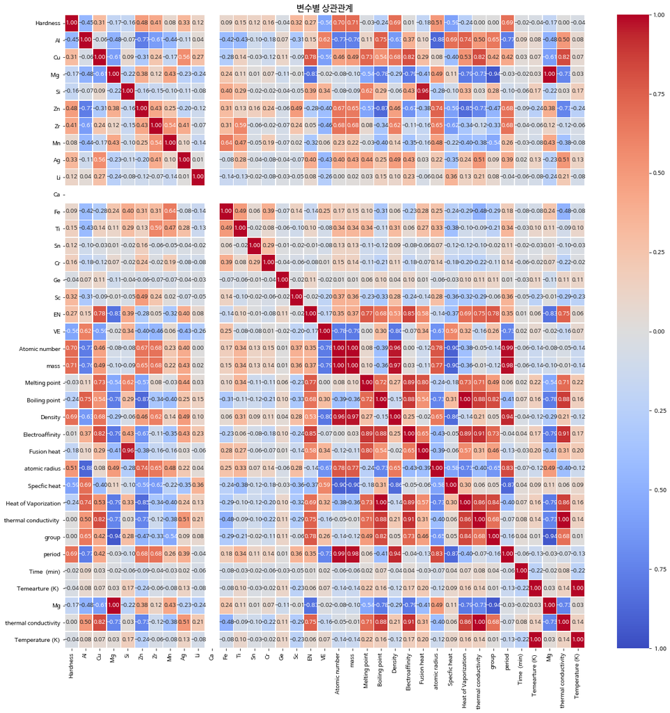

```python
plt.figure(figsize=(20,20))
plt.title("변수별 상관관계", fontsize=15)
sns.heatmap(data = raw.corr(), annot=True, fmt = '.2f', linewidths=.5, cmap='coolwarm',
            vmin = -1, vmax = 1, center = 0)
```

### 3. Train set, Test set 나누기

- sklearn의 train_test_split() 함수를 사용하여 train set 60%, test set 40%의 비율로 무작위로 섞어서(shuffle=True) 분할

```python
from sklearn.model_selection import train_test_split
```

```python
X = raw[['Al', 'Cu', 'Mg', 'Si', 'Zn', 'Zr', 'Mn', 'Ag', 'Li', 'Ca',
       'Fe', 'Ti', 'Sn', 'Cr', 'Ge', 'Sc', 'EN', 'VE', 'Atomic number', 'mass',
       'Melting point', 'Boiling point', 'Density', 'Electroaffinity',
       'Fusion heat', 'atomic radius', 'Specfic heat', 'Heat of Vaporization',
       'thermal conductivity', 'group', 'period', 'Time  (min)',
       'Temperature (K)']]
y = raw['Hardness']
X_train, X_test, y_train, y_test = train_test_split(X, y, test_size=0.4, shuffle=True, random_state=12)

print('X_train shape:', X_train.shape)
print('X_test shape:', X_test.shape)
print('y_train shape:', y_train.shape)
print('y_test shape:', y_test.shape)
```

```
X_train shape: (954, 33)
X_test shape: (637, 33)
y_train shape: (954,)
y_test shape: (637,)
```

```python
X_train
```

|  | Al | Cu | Mg | Si | Zn | Zr | Mn | Ag | Li | Ca | Fe | Ti | Sn | Cr | Ge | Sc | EN | VE | Atomic number | mass | Melting point | Boiling point | Density | Electroaffinity | Fusion heat | atomic radius | Specfic heat | Heat of Vaporization | thermal conductivity | … |
| --- | --- | --- | --- | --- | --- | --- | --- | --- | --- | --- | --- | --- | --- | --- | --- | --- | --- | --- | --- | --- | --- | --- | --- | --- | --- | --- | --- | --- | --- | --- |
| 820 | 0.956 | 0.0250 | 0.0150 | 0.0025 | 0.0000 | 0.0000 | 0.0000 | 0.0010 | 0.0 | 0 | 0.0000 | 0.0000 | 0.0 | 0.0000 | 0.0 | 0.0 | 1.612990 | 2.9340 | 13.4150 | 27.9500 | 672.3060 | 2500.2260 | 2.847415 | 44.04900 | 10.82400 | 119.0505 | 891.1340 | 290.6805 | 237.8650 | … |
| 667 | 0.978 | 0.0031 | 0.0110 | 0.0064 | 0.0000 | 0.0000 | 0.0000 | 0.0000 | 0.0 | 0 | 0.0008 | 0.0007 | 0.0 | 0.0000 | 0.0 | 0.0 | 1.609582 | 2.9891 | 13.0617 | 27.1260 | 667.4380 | 2506.9429 | 2.711764 | 42.80496 | 10.94632 | 118.4069 | 901.7896 | 291.7647 | 233.8686 | … |
| 1447 | 0.903 | 0.0015 | 0.0510 | 0.0015 | 0.0300 | 0.0015 | 0.0080 | 0.0000 | 0.0 | 0 | 0.0020 | 0.0007 | 0.0 | 0.0003 | 0.0 | 0.0 | 1.595471 | 2.9491 | 13.6501 | 28.4307 | 663.0132 | 2397.7107 | 2.847797 | 38.86776 | 10.60519 | 120.6750 | 887.2584 | 279.3887 | 225.7921 | … |
| 903 | 0.878 | 0.0224 | 0.0195 | 0.0000 | 0.0782 | 0.0016 | 0.0000 | 0.0000 | 0.0 | 0 | 0.0000 | 0.0000 | 0.0 | 0.0000 | 0.0 | 0.0 | 1.612843 | 2.8582 | 14.7076 | 30.8362 | 652.1704 | 2370.3236 | 3.173803 | 40.03292 | 10.46606 | 121.1135 | 852.9900 | 276.7038 | 227.9908 | … |
| 1192 | 0.960 | 0.0250 | 0.0150 | 0.0000 | 0.0000 | 0.0000 | 0.0000 | 0.0000 | 0.0 | 0 | 0.0000 | 0.0000 | 0.0 | 0.0000 | 0.0 | 0.0 | 1.612750 | 2.9350 | 13.3850 | 27.8800 | 670.4500 | 2500.8900 | 2.841950 | 43.76000 | 10.73000 | 119.0800 | 892.7400 | 290.7000 | 238.0000 | … |
| ... | ... | ... | ... | ... | ... | ... | ... | ... | ... | ... | ... | ... | ... | ... | ... | ... | ... | ... | ... | ... | ... | ... | ... | ... | ... | ... | ... | ... | ... | … |
| 432 | 0.957 | 0.0250 | 0.0150 | 0.0025 | 0.0000 | 0.0000 | 0.0000 | 0.0000 | 0.0 | 0 | 0.0000 | 0.0000 | 0.0 | 0.0000 | 0.0 | 0.0 | 1.612670 | 2.9360 | 13.3810 | 27.8690 | 672.0050 | 2500.5830 | 2.839675 | 43.96650 | 10.82340 | 119.0035 | 891.8030 | 290.7185 | 237.6700 | … |
| 1283 | 0.938 | 0.0470 | 0.0080 | 0.0002 | 0.0000 | 0.0016 | 0.0026 | 0.0014 | 0.0 | 0 | 0.0003 | 0.0005 | 0.0 | 0.0000 | 0.0 | 0.0 | 1.620519 | 2.9064 | 13.8694 | 29.0122 | 684.3592 | 2514.7076 | 3.017013 | 45.70579 | 10.82917 | 119.7952 | 876.7159 | 292.2034 | 241.5737 | … |
| 1265 | 0.935 | 0.0480 | 0.0072 | 0.0004 | 0.0000 | 0.0016 | 0.0027 | 0.0036 | 0.0 | 0 | 0.0002 | 0.0004 | 0.0 | 0.0000 | 0.0 | 0.0 | 1.620985 | 2.8999 | 13.9537 | 29.2143 | 685.1442 | 2513.8583 | 3.039430 | 45.99608 | 10.83618 | 119.8383 | 874.1819 | 292.0996 | 242.1143 | … |
| 1277 | 0.938 | 0.0470 | 0.0080 | 0.0002 | 0.0000 | 0.0016 | 0.0026 | 0.0014 | 0.0 | 0 | 0.0003 | 0.0005 | 0.0 | 0.0000 | 0.0 | 0.0 | 1.620519 | 2.9064 | 13.8694 | 29.0122 | 684.3592 | 2514.7076 | 3.017013 | 45.70579 | 10.82917 | 119.7952 | 876.7159 | 292.2034 | 241.5737 | … |
| 1414 | 0.903 | 0.0015 | 0.0510 | 0.0015 | 0.0300 | 0.0015 | 0.0080 | 0.0000 | 0.0 | 0 | 0.0020 | 0.0007 | 0.0 | 0.0003 | 0.0 | 0.0 | 1.595471 | 2.9491 | 13.6501 | 28.4307 | 663.0132 | 2397.7107 | 2.847797 | 38.86776 | 10.60519 | 120.6750 | 887.2584 | 279.3887 | 225.7921 | … |

954 rows × 33 columns

```python
# 학습데이터셋 저장
paper2_train = pd.concat([X_train,y_train],axis=1)
paper2_train.to_csv('paper2_trainset.csv') # 학습 데이터셋 저장
paper2_train
```

|  | Al | Cu | Mg | Si | Zn | Zr | Mn | Ag | Li | Ca | Fe | Ti | Sn | Cr | Ge | Sc | EN | VE | Atomic number | mass | Melting point | Boiling point | Density | Electroaffinity | Fusion heat | atomic radius | Specfic heat | Heat of Vaporization | thermal conductivity | … |
| --- | --- | --- | --- | --- | --- | --- | --- | --- | --- | --- | --- | --- | --- | --- | --- | --- | --- | --- | --- | --- | --- | --- | --- | --- | --- | --- | --- | --- | --- | --- |
| 820 | 0.956 | 0.0250 | 0.0150 | 0.0025 | 0.0000 | 0.0000 | 0.0000 | 0.0010 | 0.0 | 0 | 0.0000 | 0.0000 | 0.0 | 0.0000 | 0.0 | 0.0 | 1.612990 | 2.9340 | 13.4150 | 27.9500 | 672.3060 | 2500.2260 | 2.847415 | 44.04900 | 10.82400 | 119.0505 | 891.1340 | 290.6805 | 237.8650 | … |
| 667 | 0.978 | 0.0031 | 0.0110 | 0.0064 | 0.0000 | 0.0000 | 0.0000 | 0.0000 | 0.0 | 0 | 0.0008 | 0.0007 | 0.0 | 0.0000 | 0.0 | 0.0 | 1.609582 | 2.9891 | 13.0617 | 27.1260 | 667.4380 | 2506.9429 | 2.711764 | 42.80496 | 10.94632 | 118.4069 | 901.7896 | 291.7647 | 233.8686 | … |
| 1447 | 0.903 | 0.0015 | 0.0510 | 0.0015 | 0.0300 | 0.0015 | 0.0080 | 0.0000 | 0.0 | 0 | 0.0020 | 0.0007 | 0.0 | 0.0003 | 0.0 | 0.0 | 1.595471 | 2.9491 | 13.6501 | 28.4307 | 663.0132 | 2397.7107 | 2.847797 | 38.86776 | 10.60519 | 120.6750 | 887.2584 | 279.3887 | 225.7921 | … |
| 903 | 0.878 | 0.0224 | 0.0195 | 0.0000 | 0.0782 | 0.0016 | 0.0000 | 0.0000 | 0.0 | 0 | 0.0000 | 0.0000 | 0.0 | 0.0000 | 0.0 | 0.0 | 1.612843 | 2.8582 | 14.7076 | 30.8362 | 652.1704 | 2370.3236 | 3.173803 | 40.03292 | 10.46606 | 121.1135 | 852.9900 | 276.7038 | 227.9908 | … |
| 1192 | 0.960 | 0.0250 | 0.0150 | 0.0000 | 0.0000 | 0.0000 | 0.0000 | 0.0000 | 0.0 | 0 | 0.0000 | 0.0000 | 0.0 | 0.0000 | 0.0 | 0.0 | 1.612750 | 2.9350 | 13.3850 | 27.8800 | 670.4500 | 2500.8900 | 2.841950 | 43.76000 | 10.73000 | 119.0800 | 892.7400 | 290.7000 | 238.0000 | … |
| ... | ... | ... | ... | ... | ... | ... | ... | ... | ... | ... | ... | ... | ... | ... | ... | ... | ... | ... | ... | ... | ... | ... | ... | ... | ... | ... | ... | ... | ... | … |
| 432 | 0.957 | 0.0250 | 0.0150 | 0.0025 | 0.0000 | 0.0000 | 0.0000 | 0.0000 | 0.0 | 0 | 0.0000 | 0.0000 | 0.0 | 0.0000 | 0.0 | 0.0 | 1.612670 | 2.9360 | 13.3810 | 27.8690 | 672.0050 | 2500.5830 | 2.839675 | 43.96650 | 10.82340 | 119.0035 | 891.8030 | 290.7185 | 237.6700 | … |
| 1283 | 0.938 | 0.0470 | 0.0080 | 0.0002 | 0.0000 | 0.0016 | 0.0026 | 0.0014 | 0.0 | 0 | 0.0003 | 0.0005 | 0.0 | 0.0000 | 0.0 | 0.0 | 1.620519 | 2.9064 | 13.8694 | 29.0122 | 684.3592 | 2514.7076 | 3.017013 | 45.70579 | 10.82917 | 119.7952 | 876.7159 | 292.2034 | 241.5737 | … |
| 1265 | 0.935 | 0.0480 | 0.0072 | 0.0004 | 0.0000 | 0.0016 | 0.0027 | 0.0036 | 0.0 | 0 | 0.0002 | 0.0004 | 0.0 | 0.0000 | 0.0 | 0.0 | 1.620985 | 2.8999 | 13.9537 | 29.2143 | 685.1442 | 2513.8583 | 3.039430 | 45.99608 | 10.83618 | 119.8383 | 874.1819 | 292.0996 | 242.1143 | … |
| 1277 | 0.938 | 0.0470 | 0.0080 | 0.0002 | 0.0000 | 0.0016 | 0.0026 | 0.0014 | 0.0 | 0 | 0.0003 | 0.0005 | 0.0 | 0.0000 | 0.0 | 0.0 | 1.620519 | 2.9064 | 13.8694 | 29.0122 | 684.3592 | 2514.7076 | 3.017013 | 45.70579 | 10.82917 | 119.7952 | 876.7159 | 292.2034 | 241.5737 | … |
| 1414 | 0.903 | 0.0015 | 0.0510 | 0.0015 | 0.0300 | 0.0015 | 0.0080 | 0.0000 | 0.0 | 0 | 0.0020 | 0.0007 | 0.0 | 0.0003 | 0.0 | 0.0 | 1.595471 | 2.9491 | 13.6501 | 28.4307 | 663.0132 | 2397.7107 | 2.847797 | 38.86776 | 10.60519 | 120.6750 | 887.2584 | 279.3887 | 225.7921 | … |

954 rows × 34 columns

```python
# 검증데이터셋 저장
paper2_test = pd.concat([X_test,y_test],axis=1)
paper2_test.to_csv('paper2_testset.csv') # 검증 데이터셋 저장
paper2_test
```

|  | Al | Cu | Mg | Si | Zn | Zr | Mn | Ag | Li | Ca | Fe | Ti | Sn | Cr | Ge | Sc | EN | VE | Atomic number | mass | Melting point | Boiling point | Density | Electroaffinity | Fusion heat | atomic radius | Specfic heat | Heat of Vaporization | thermal conductivity | … |
| --- | --- | --- | --- | --- | --- | --- | --- | --- | --- | --- | --- | --- | --- | --- | --- | --- | --- | --- | --- | --- | --- | --- | --- | --- | --- | --- | --- | --- | --- | --- |
| 248 | 0.973 | 0.0121 | 0.0119 | 0.0000 | 0.0000 | 0.0000 | 0.0021 | 0.0000 | 0.000 | 0 | 0.000 | 0.0000 | 0.0 | 0.0 | 0.000 | 0.0 | 1.608364 | 2.9696 | 13.1952 | 27.4465 | 665.6480 | 2500.3753 | 2.771727 | 42.78514 | 10.70086 | 118.6321 | 897.3823 | 290.7042 | 235.5607 | … |
| 1506 | 0.906 | 0.0380 | 0.0026 | 0.0500 | 0.0000 | 0.0000 | 0.0000 | 0.0000 | 0.000 | 0 | 0.002 | 0.0008 | 0.0 | 0.0 | 0.000 | 0.0 | 1.634158 | 2.9684 | 13.6808 | 28.5068 | 715.9524 | 2539.1756 | 2.927018 | 49.72168 | 12.76718 | 118.7978 | 873.0820 | 296.1748 | 236.2016 | … |
| 1529 | 0.906 | 0.0380 | 0.0026 | 0.0500 | 0.0000 | 0.0000 | 0.0000 | 0.0000 | 0.000 | 0 | 0.002 | 0.0008 | 0.0 | 0.0 | 0.000 | 0.0 | 1.634158 | 2.9684 | 13.6808 | 28.5068 | 715.9524 | 2539.1756 | 2.927018 | 49.72168 | 12.76718 | 118.7978 | 873.0820 | 296.1748 | 236.2016 | … |
| 269 | 0.963 | 0.0189 | 0.0156 | 0.0000 | 0.0000 | 0.0000 | 0.0021 | 0.0000 | 0.000 | 0 | 0.000 | 0.0000 | 0.0 | 0.0 | 0.000 | 0.0 | 1.610031 | 2.9538 | 13.3068 | 27.7005 | 668.8242 | 2497.2519 | 2.812056 | 43.16526 | 10.71513 | 118.9746 | 894.7275 | 290.2878 | 236.5227 | … |
| 1086 | 0.945 | 0.0350 | 0.0035 | 0.0000 | 0.0060 | 0.0000 | 0.0000 | 0.0011 | 0.009 | 0 | 0.000 | 0.0000 | 0.0 | 0.0 | 0.000 | 0.0 | 1.613378 | 2.8991 | 13.6007 | 28.4108 | 669.1061 | 2496.9882 | 2.930249 | 44.98040 | 10.68398 | 119.6290 | 906.0065 | 290.1325 | 238.5930 | … |
| ... | ... | ... | ... | ... | ... | ... | ... | ... | ... | ... | ... | ... | ... | ... | ... | ... | ... | ... | ... | ... | ... | ... | ... | ... | ... | ... | ... | ... | ... | … |
| 1031 | 0.984 | 0.0030 | 0.0052 | 0.0075 | 0.0000 | 0.0000 | 0.0000 | 0.0000 | 0.000 | 0 | 0.000 | 0.0000 | 0.0 | 0.0 | 0.000 | 0.0 | 1.611002 | 2.9954 | 13.0464 | 27.0948 | 666.6770 | 2514.0700 | 2.710151 | 43.17720 | 10.98984 | 118.1335 | 901.3170 | 292.5701 | 234.3970 | … |
| 485 | 0.955 | 0.0250 | 0.0150 | 0.0050 | 0.0000 | 0.0000 | 0.0000 | 0.0000 | 0.000 | 0 | 0.000 | 0.0000 | 0.0 | 0.0 | 0.000 | 0.0 | 1.614200 | 2.9400 | 13.3900 | 27.8850 | 674.2200 | 2502.7950 | 2.840100 | 44.21550 | 10.92750 | 119.0450 | 891.7700 | 291.0300 | 237.5750 | … |
| 740 | 0.955 | 0.0250 | 0.0150 | 0.0000 | 0.0000 | 0.0000 | 0.0000 | 0.0039 | 0.000 | 0 | 0.000 | 0.0000 | 0.0 | 0.0 | 0.000 | 0.0 | 1.612227 | 2.9239 | 13.5033 | 28.1662 | 670.8979 | 2496.7268 | 2.869166 | 44.03500 | 10.72057 | 119.1335 | 889.1365 | 290.2295 | 238.5020 | … |
| 56 | 0.973 | 0.0023 | 0.0092 | 0.0078 | 0.0064 | 0.0012 | 0.0010 | 0.0000 | 0.000 | 0 | 0.000 | 0.0000 | 0.0 | 0.0 | 0.000 | 0.0 | 1.611478 | 2.9955 | 13.2003 | 27.4376 | 667.8360 | 2502.8912 | 2.742746 | 42.71622 | 10.99827 | 118.6643 | 898.6930 | 291.4344 | 233.2096 | … |
| 879 | 0.959 | 0.0350 | 0.0040 | 0.0000 | 0.0000 | 0.0000 | 0.0000 | 0.0000 | 0.000 | 0 | 0.000 | 0.0000 | 0.0 | 0.0 | 0.002 | 0.0 | 1.619750 | 2.9280 | 13.5940 | 28.3750 | 675.3560 | 2518.5410 | 2.920460 | 45.13950 | 10.81820 | 119.0670 | 885.0980 | 292.6670 | 240.1250 | … |

637 rows × 34 columns

### 모델 학습(GradientBoostingClassifier)

- https://stackabuse.com/gradient-boosting-classifiers-in-python-with-scikit-learn/
- https://blog.naver.com/baek2sm/221769091385
- https://woolulu.tistory.com/30

gradient boosting regression tree는 여러 개의 decision tree를 묶어 강력한 model을 만드는 ensemble기법으로, 이 모델은 이전 tree의 오차를 보완하는 방식으로 tree를 만듭니다.

gradinet boosting에서 주요 parameter는 이전 트리의 오차를 얼마나 강하게 보정할 것인가를 제어하는 *learning_rate*가 있습니다. learning_rate를 높이면 보정을 강하게 하기 때문에 복잡한 모델을 만듭니다.

또한 n_estimator 값을 키우면 ensemble에 트리가 더 많이 추가되어 모델의 복잡도가 커지고 train 세트를 더 정확하게 fitting합니다.

**Explore # of Trees:** More trees may require a smaller learning rate, fewer trees may require a larger learning rate. *The number of trees* can be set via the “**n_estimators**” argument and defaults to 100.

```python
from sklearn.preprocessing import MinMaxScaler, StandardScaler
from sklearn.model_selection import train_test_split
from sklearn.metrics import classification_report, confusion_matrix
from sklearn.ensemble import GradientBoostingClassifier, GradientBoostingRegressor
```

```python
X_train.columns
```

```
Index(['Al', 'Cu', 'Mg', 'Si', 'Zn', 'Zr', 'Mn', 'Ag', 'Li', 'Ca', 'Fe', 'Ti',
       'Sn', 'Cr', 'Ge', 'Sc', 'EN', 'VE', 'Atomic number', 'mass',
       'Melting point', 'Boiling point', 'Density', 'Electroaffinity',
       'Fusion heat', 'atomic radius', 'Specfic heat', 'Heat of Vaporization',
       'thermal conductivity', 'group', 'period', 'Time  (min)',
       'Temperature (K)'],
      dtype='object')
```

논문에서 제외된 Features

- Atomic number, mass, density, period, Electroaffinity, thermal conductivity, group

```python
# 컬럼 제외
X_train = X_train[['Al', 'Cu', 'Mg', 'Si', 'Zn', 'Zr', 'Mn', 'Ag', 'Li', 'Ca', 'Fe', 'Ti',
       'Sn', 'Cr', 'Ge', 'Sc', 'EN', 'VE',
       'Melting point', 'Boiling point',
       'Fusion heat', 'atomic radius', 'Specfic heat', 'Heat of Vaporization',
       'Time  (min)','Temperature (K)']]

X_test =  X_test[['Al', 'Cu', 'Mg', 'Si', 'Zn', 'Zr', 'Mn', 'Ag', 'Li', 'Ca', 'Fe', 'Ti',
       'Sn', 'Cr', 'Ge', 'Sc', 'EN', 'VE',
       'Melting point', 'Boiling point',
       'Fusion heat', 'atomic radius', 'Specfic heat', 'Heat of Vaporization',
       'Time  (min)',
       'Temperature (K)']]
```

```python
X_train.columns
```

```
Index(['Al', 'Cu', 'Mg', 'Si', 'Zn', 'Zr', 'Mn', 'Ag', 'Li', 'Ca', 'Fe', 'Ti',
       'Sn', 'Cr', 'Ge', 'Sc', 'EN', 'VE', 'Melting point', 'Boiling point',
       'Fusion heat', 'atomic radius', 'Specfic heat', 'Heat of Vaporization',
       'Time  (min)', 'Temperature (K)'],
      dtype='object')
```

```python
scaler = StandardScaler()
X_train = scaler.fit_transform(X_train)
X_test = scaler.transform(X_test)
```

- 논문의 Experiment Hyperparameter

Criterion = gain ratio, Max depth = 7, number of trees = 150, Learning rate = 0.01

```python
gb_clf = GradientBoostingClassifier(n_estimators=150,
                                    learning_rate=0.01, max_features=3, max_depth=7, random_state=0)
gb_clf.fit(X_train, y_train)

print("Accuracy score (training): {0:.3f}".format(gb_clf.score(X_train, y_train)))

y_pred = gb_clf.predict(X_test)
print("Accuracy score (validation): {0:.3f}".format(gb_clf.score(X_test, y_test)))
```

```
Accuracy score (training): 0.972
Accuracy score (validation): 0.107
```

### 예측 결과 평가(Gradient Boosting Classifier)

```
MSE:  65.2072213500785
RMSE:  8.07509884460113
MAE:  5.194662480376766
R2:  0.9324385411412234
```

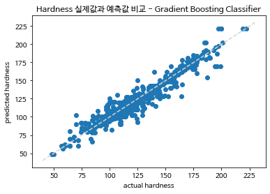

```python
from sklearn.metrics import mean_squared_error
from sklearn.metrics import mean_absolute_error
from sklearn.metrics import r2_score

RMSE = mean_squared_error(y_test, y_pred)**0.5
print('MSE: ', mean_squared_error(y_test, y_pred))
print('RMSE: ',RMSE)
print('MAE: ', mean_absolute_error(y_test, y_pred))
print('R2: ', r2_score(y_test, y_pred))

# 시각화
x=np.linspace(40, 230, len(y_test))
y=x
plt.plot(x,y, color='lightgrey', linestyle='--')

plt.scatter(y_test, y_pred)
plt.title("Hardness 실제값과 예측값 비교 - Gradient Boosting Classifier")
plt.xlabel("actual hardness")
plt.ylabel("predicted hardness")
plt.show()
```

```python
# lr 찾기
lr_list = [0.01, 0.02, 0.03, 0.04, 0.05]
for learning_rate in lr_list:
  gb_clf = GradientBoostingClassifier(n_estimators=20, learning_rate=learning_rate, max_features=3, max_depth=5, random_state=0)
  gb_clf.fit(X_train, y_train)

  print("Learning rate: ", learning_rate)
  print("Accuracy score (training): {0:.3f}".format(gb_clf.score(X_train, y_train)))
  print("Accuracy score (validation): {0:.3f}".format(gb_clf.score(X_test, y_test)))
```

```
Learning rate:  0.01
Accuracy score (training): 0.795
Accuracy score (validation): 0.097
Learning rate:  0.02
Accuracy score (training): 0.832
Accuracy score (validation): 0.083
Learning rate:  0.03
Accuracy score (training): 0.865
Accuracy score (validation): 0.086
Learning rate:  0.04
Accuracy score (training): 0.879
Accuracy score (validation): 0.091
Learning rate:  0.05
Accuracy score (training): 0.904
Accuracy score (validation): 0.089
```

```python
from xgboost import XGBClassifier
xgb_clf = XGBClassifier()
xgb_clf.fit(X_train, y_train)
score = xgb_clf.score(X_test, y_test)
print(score)
```

```
0.09105180533751962
```

### 예측 결과 평가(RandomForest)

```python
result = pd.read_csv("paper2_predict.csv")
result.info()
```

```
<class 'pandas.core.frame.DataFrame'>
RangeIndex: 637 entries, 0 to 636
Data columns (total 37 columns):
 #   Column                Non-Null Count  Dtype
---  ------                --------------  -----
 0   model                 637 non-null    object
 1   Unnamed: 1            637 non-null    int64
 2   Al                    637 non-null    float64
 3   Cu                    637 non-null    float64
 4   Mg                    637 non-null    float64
 5   Si                    637 non-null    float64
 6   Zn                    637 non-null    float64
 7   Zr                    637 non-null    float64
 8   Mn                    637 non-null    float64
 9   Ag                    637 non-null    float64
```

[output cut: 29 more lines]

```python
from sklearn.metrics import mean_squared_error
from sklearn.metrics import mean_absolute_error
```

```
RMSE:  19.267979192547788
MAE:  13.677003750218034
```

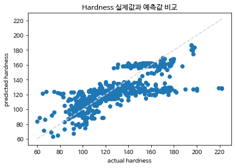

```python
RMSE = mean_squared_error(result['Hardness'], result['(Predicted) Hardness'])**0.5
print('RMSE: ',RMSE)
print('MAE: ', mean_absolute_error(result['Hardness'], result['(Predicted) Hardness']))

x=np.linspace(min(result['Hardness']),max(result['Hardness']), len(result['Hardness']))
y=x
plt.plot(x,y, color='lightgrey', linestyle='--')

plt.scatter(result['Hardness'], result['(Predicted) Hardness'])
plt.title("Hardness 실제값과 예측값 비교")
plt.xlabel("actual hardness")
plt.ylabel("predicted hardness")
plt.show()
```